# Practical 4 Supervised learning: Regression 1

Supervised Learning & Visualization

Ernst Paul Swens

November, 2022

# Q1

**Create a linear model object called `lm_ses` using the formula `medv ~ lstat` and the `Boston` dataset.**

```r
lm_ses <- lm(medv ~ lstat, data = Boston)
```

# Q2

**Use the function `coef()` to extract the intercept and slope from the lm_ses object. Interpret the slope coefficient.**

```r
coef(lm_ses)
```

```
## (Intercept)       lstat
##  34.5538409  -0.9500494
```

```r
# for lstat = 0, the medv is 34.6
# for each 1 increase of lstat medv decreases with -0.95
```

# Q3

**Use `summary()` to get a summary of the `lm_ses` object. What do you see? You can use the help file `?summary.lm`.**

```r
summary(lm_ses)
```

```
##
## Call:
## lm(formula = medv ~ lstat, data = Boston)
##
## Residuals:
##     Min      1Q  Median      3Q     Max
## -15.168  -3.990  -1.318   2.034  24.500
##
## Coefficients:
##             Estimate Std. Error t value Pr(>|t|)
## (Intercept) 34.55384    0.56263   61.41   <2e-16 ***
## lstat       -0.95005    0.03873  -24.53   <2e-16 ***
## ---
## Signif. codes:  0 '***' 0.001 '**' 0.01 '*' 0.05 '.' 0.1 ' ' 1
##
## Residual standard error: 6.216 on 504 degrees of freedom
## Multiple R-squared:  0.5441, Adjusted R-squared:  0.5432
## F-statistic: 601.6 on 1 and 504 DF,  p-value: < 2.2e-16
```

# Q4

**Save the predicted y values to a variable called `y_pred`**

```r
y_pred <- predict(lm_ses)
```

# Q5

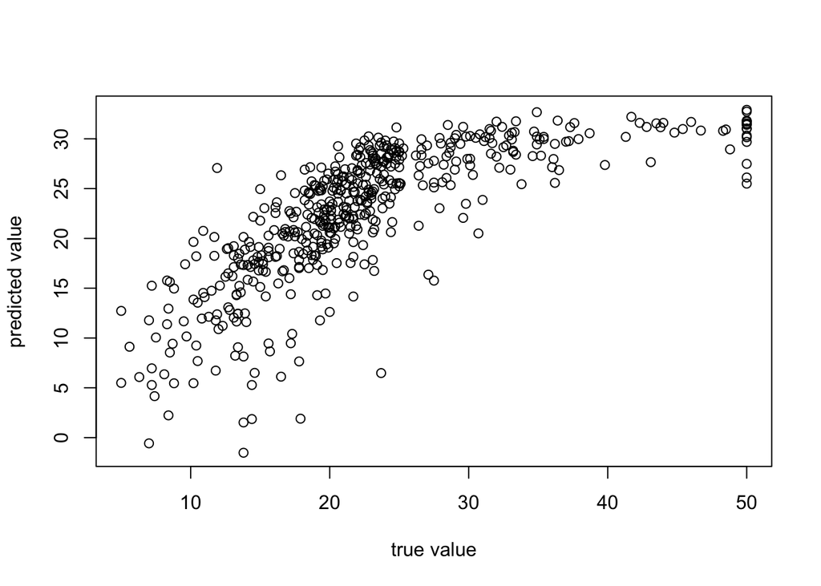

```r
plot(Boston$medv, y_pred,
     xlab = "true value",
     ylab = "predicted value")
```

# Q6

**Use the `seq()` function to generate a sequence of 1000 equally spaced values from 0 to 40. Store this vector in a data frame with (`data.frame()` or `tibble()`) as its column name `lstat.` Name the data frame `pred_dat`.**

```r
pred_dat <- data.frame(lstat = seq(from = 0, to = 40, length.out = 1000))
```

# Q7

**Use the newly created data frame as the newdata argument to a `predict()` call for `lm_ses`. Store it in a variable named `y_pred_new`.**

```r
y_pred_new <- predict(lm_ses, newdata = pred_dat)
```

# Q8

**Create a scatter plot from the `Boston` dataset with `lstat` mapped to the x position and `medv` mapped to the y position. Store the plot in an object called `p_scatter`.**

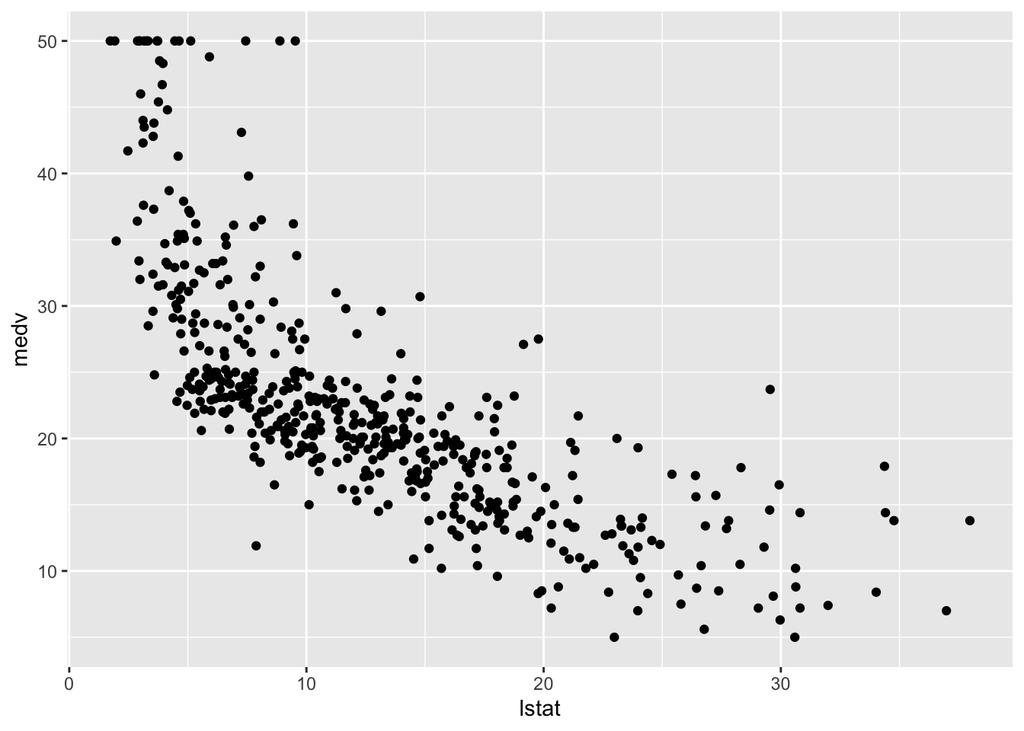

```r
Boston %>%
   ggplot(aes(x = lstat, y = medv)) +
   geom_point()
```

# Q9

**Add the vector `y_pred_new` to the `pred_dat` data frame with the name medv.**

```r
pred_dat$medv <- y_pred_new
```

# Q10

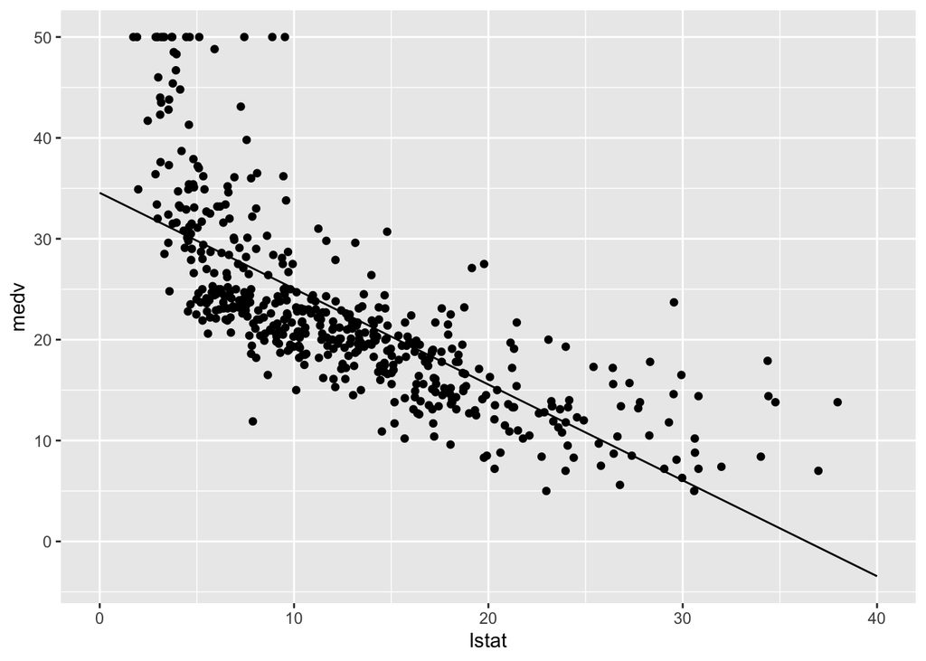

```r
Boston %>%
   ggplot(aes(x = lstat, y = medv)) +
   geom_point() +
   geom_line(data = pred_dat)
```

# Q11

**The interval argument can be used to generate confidence or prediction intervals. Create a new object called `y_pred_95` using `predict()` (again with the `pred_dat` data) with the `interval` argument set to “confidence”. What is in this object?**

```r
y_pred_95 <- predict(lm_ses, pred_dat, interval = "confidence")

head(y_pred_95)
```

```
##        fit      lwr      upr
## 1 34.55384 33.44846 35.65922
## 2 34.51580 33.41307 35.61853
## 3 34.47776 33.37768 35.57784
## 4 34.43972 33.34229 35.53715
## 5 34.40168 33.30690 35.49646
## 6 34.36364 33.27150 35.45578
```

# Q12

**Create a data frame with 4 columns: `medv`, `lstat`, `lower`, and `upper`.**

```r
gg_pred <- tibble(
   lstat = pred_dat$lstat,
   medv  = y_pred_95[, 1],
   lower = y_pred_95[, 2],
   upper = y_pred_95[, 3]
)
```

# Q13

**Add a `geom_ribbon()` to the plot with the data frame you just made. The ribbon geom requires three aesthetics: x (lstat, already mapped), ymin (lower), and ymax (upper). Add the ribbon below the geom_line() and the geom_points() of before to make sure those remain visible. Give it a nice colour and clean up the plot, too!**

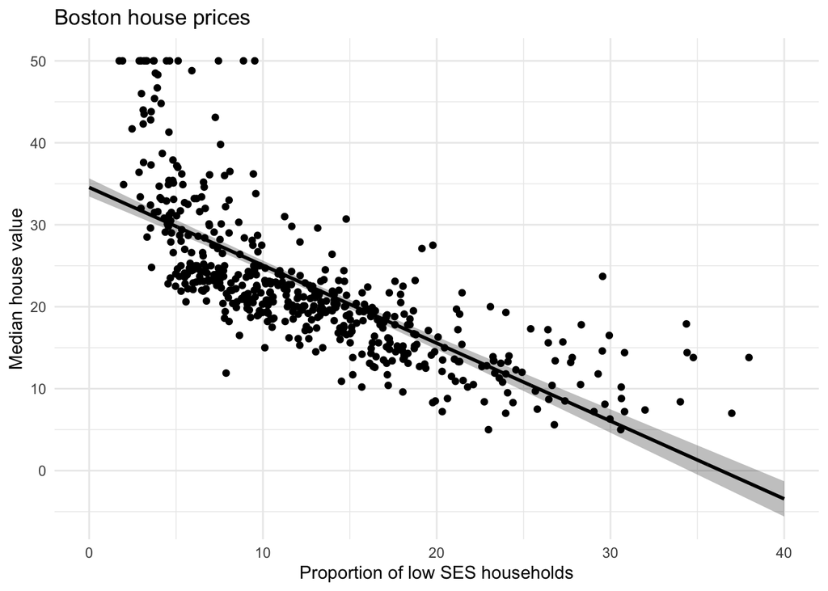

```r
Boston %>%
  ggplot(aes(x = lstat, y = medv)) +
  geom_ribbon(aes(ymin = lower, ymax = upper), data = gg_pred, alpha = 0.3) +
  geom_point() +
  geom_line(data = pred_dat, size = 1) +
  theme_minimal() +
  labs(x    = "Proportion of low SES households",
       y    = "Median house value",
       title = "Boston house prices")
```

# Q14

**Explain in your own words what the ribbon represents.**

```r
# that is the 95% confidence interval. It tells something about the uncertainty
# of the regression coefficient.
# If we would take 100 samples, and derive 100 CI, then 95 % of those CI would
# contain the true parameter.
```

# Q15

**Do the same thing, but now with the prediction interval instead of the confidence interval.**

```r
y_pred_95 <- predict(lm_ses, pred_dat, interval = "prediction")

head(y_pred_95)
```

```
##        fit      lwr      upr
## 1 34.55384 22.29192 46.81576
## 2 34.51580 22.25412 46.77748
## 3 34.47776 22.21632 46.73920
## 4 34.43972 22.17852 46.70092
## 5 34.40168 22.14071 46.66265
## 6 34.36364 22.10291 46.62437
```

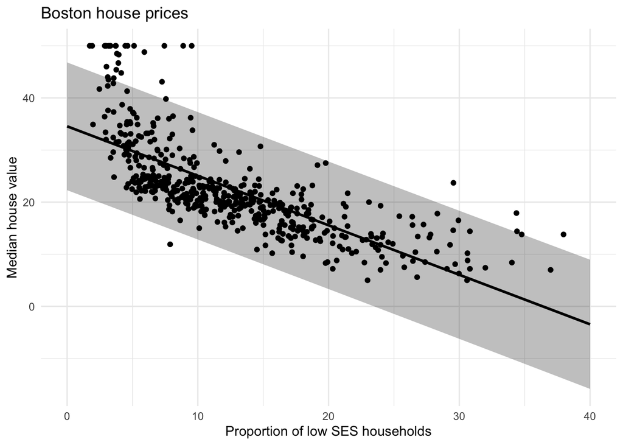

```r
gg_pred <- tibble(
   lstat = pred_dat$lstat,
   medv  = y_pred_95[, 1],
   lower = y_pred_95[, 2],
   upper = y_pred_95[, 3]
)

Boston %>%
  ggplot(aes(x = lstat, y = medv)) +
  geom_ribbon(aes(ymin = lower, ymax = upper), data = gg_pred, alpha = 0.3) +
  geom_point() +
  geom_line(data = pred_dat, size = 1) +
  theme_minimal() +
  labs(x    = "Proportion of low SES households",
       y    = "Median house value",
       title = "Boston house prices")
```